# Taller 1 — Minería de Datos (Webscraping, SQL y Análisis de Datos

Categoría elegida: Primeros auxilios y curación

Autor/a

Johan Steven Avilán Peñaloza

Fecha de publicación

10-10-2026

# 1 Introducción y alcance

Este informe compara los precios de productos de la categoría **Primeros auxilios y curación** (gasas, vendas, apósitos, curitas, esparadrapos, antisépticos para heridas y kits de curación) en tres comercios en línea de Colombia. Los datos provienen del código de extracción (`scraper.R`), se almacenan en una base SQLite (`comparador_precios.sqlite`) y se analizan con consultas SQL.

Todo el proceso (extracción, limpieza, carga en SQLite, consultas y gráficos) se realizó en **R**.

# 2 Fuentes y estrategia de extracción

## 2.1 Comercios consultados

| Comercio | Sección consultada | Técnica de extracción |
| --- | --- | --- |
| **Farmatodo** | `farmatodo.com.co/categorias/salud-y-medicamentos/botiquin-y-primeros-auxilios`, subcategorías *curitas, algodones, adhesivos y botiquín*, *antisépticos*, *vendas* y *compresas* | Página dinámica leída con Chrome automatizado (`rvest::read_html_live()`), pulsando “Cargar más” hasta agotar el listado |
| **La Rebaja** | `larebajavirtual.com/drogueria/cuidado-de-la-herida` | Servicio JSON interno de la tienda (`/api/catalog_system/pub/products/search`), páginas de 50 productos |
| **Locatel** | `locatelcolombia.com/drogueria/cuidado-heridas` | Mismo servicio JSON de La Rebaja (ambas son tiendas VTEX) |

La Rebaja y Locatel declaran el total de productos de la sección en la cabecera de la respuesta, y eso permite comprobar que la extracción está completa. En Farmatodo no existe ese total, y la completitud se verifica porque el botón “Cargar más” desaparece y el conteo deja de crecer.

Los sitios se visualizaron desde **Bogotá** para contrastar precios. La Rebaja indica que sus precios varían según la ciudad de entrega, y Locatel y Farmatodo que sus precios y promociones en línea pueden diferir de los de las tiendas físicas. Las consultas al servicio de catálogo VTEX (La Rebaja y Locatel) no fijan una ciudad explícita, por lo que devuelven el precio por defecto del sitio.

## 2.2 Estrategia de extracción y selectores

**Farmatodo (página dinámica).** Las tarjetas de producto se cargan con JavaScript y el listado inicial trae solo 24 productos. El desplazamiento (*scroll*) no carga más: lo que carga más es el botón **«Cargar más»**, que el código pulsa (a través de `chromote`, la sesión que abre `rvest::read_html_live()`) hasta que el número de productos deja de crecer, con una espera adicional de 6 segundos antes de darlo por agotado. Con una petición HTTP simple solo se obtenían 56 productos por sección (un tope del HTML inicial), y por eso se usa el navegador automatizado. Se recorren cuatro subcategorías de *Botiquín y primeros auxilios*: `curitas-algodones-adhesivos-y-botiquin`, `antisepticos`, `vendas` y `compresas`. Las subcategorías **«Jeringas, guantes y material hospitalario»** y **«Aparatos médicos y pastilleros»** se excluyeron por completo por no pertenecer a la categoría.

| Dato | Selector CSS en Farmatodo |
| --- | --- |
| Tarjeta de producto | `div.product-card-handler` |
| Nombre y enlace | `a.product-card-handler__detail-description` (respaldo: `a.product-card-handler__image-link`) |
| SKU | número de la URL `/producto/<SKU>-...`; respaldo: atributo `data-test="product-card-<SKU>"` |
| Precio | `app-product-all-price` (si hay dos montos, el menor es el vigente y el mayor el anterior) |
| Marca | `.product-card-handler__brand-value` |
| Precio por unidad que muestra el sitio | `.product-card-handler__pum` |
| Vendedor externo | texto «Vendido por: …» dentro de la tarjeta |

## 2.3 Buenas prácticas aplicadas

- Pausa de 1 segundo entre peticiones a las tiendas VTEX y de varios segundos entre acciones en Farmatodo, reintentos ante fallos y un *user agent* que identifica el uso académico en las peticiones HTTP a La Rebaja y Locatel. En Farmatodo, el navegador automatizado usa el *user agent* propio de Chrome.
- Conservación del **texto original** de cada anuncio (nombre, marca, presentación y precio tal como se muestran); la limpieza se hace en columnas aparte.
- **Copia cruda** de cada respuesta (HTML o JSON, comprimida con gzip) en `raw/<comercio>/<fecha>/`, y modo sin conexión que reprocesa esas copias.
- Fecha y hora de consulta (ISO 8601, hora de Colombia) en todas las observaciones.
- Una tabla de ejecuciones que registra cada corrida con su estado (completa, parcial o fallida).

## 2.4 Cumplimiento: `robots.txt` y términos de uso

Se revisaron el `robots.txt` y los términos de cada sitio en octubre de 2026.

### 2.4.1 `robots.txt`

| Comercio | Rutas que bloquea para todos los agentes | ¿Afecta lo que se consulta? |
| --- | --- | --- |
| **Farmatodo** | `/checkout*`, `/cuenta/*`, `/buscar*`, `/busqueda*`, `/sugeridos*`, `/destacados*`, `/producto/*/review`. Además prohíbe todo a los agentes «Scrapy 2.7.1» y «Scrapy 2.8.0». | No. Se leen páginas de categoría de *Botiquín y primeros auxilios*. No se usa la búsqueda ni se abren fichas de producto. |
| **La Rebaja** | `/account/*`, `/login/*`, `/checkout/*`, `/busca/*`, `/quick-view/*`, `/espiar/*`, `/cloxaquim`. | No. Se usan `/drogueria/cuidado-de-la-herida` y el servicio `/api/catalog_system/pub/products/search/`. |
| **Locatel** | `/account`, `/checkout/`, `/busca`, `/search`, `/_v/` y otras áreas del sistema, parámetros de retorno y rangos de precio. | No. Se usan `/drogueria/cuidado-heridas` y el mismo servicio de catálogo. |

Ninguno de los tres `robots.txt` menciona `/api/` ni fija una pausa entre peticiones.

### 2.4.2 Términos de uso

- **Farmatodo.** No mencionan la extracción automatizada. Prohíben la ingeniería inversa del código o los algoritmos del sitio (cláusula 5, vi), que no se realiza, y reservan los derechos sobre imágenes y texto (cláusula 11), por lo que no se descargan imágenes. Advierten que los precios pueden contener errores y diferir de los de las tiendas físicas (cláusulas 15.1 y 16).
- **La Rebaja.** Los términos y condiciones generales no mencionan la extracción automatizada. Los **términos de uso** (cláusula 4.4) declaran de propiedad exclusiva de Copservir los contenidos, textos y bases de datos del sitio, y prohíben copiarlos, reproducirlos, crear trabajos derivados o distribuirlos sin permiso escrito; solo conceden una licencia personal y no comercial para copiar los contenidos sin modificarlos. Indican además que los precios del sitio difieren de los de los puntos de venta y varían según la ciudad (cláusula 4.11).
- **Locatel.** Sus términos y condiciones (última modificación: 6 de mayo de 2020) no mencionan expresamente la extracción automatizada. Prohíben usar dispositivos o software para obstruir el sitio o acceder a información no autorizada, vender o distribuir con fines comerciales el material del sitio, y copiar o adaptar su código HTML para generar páginas (cláusula 4). Advierten que precios e información pueden contener errores (cláusula 5) y que los precios y promociones varían entre canales (cláusula 6).

### 2.4.3 Conclusión

Ninguna de las rutas consultadas está bloqueada por el `robots.txt` de su sitio, y ninguno de los términos revisados prohíbe expresamente la consulta automatizada de datos públicos del catálogo. Sin embargo, los términos de uso de La Rebaja reservan los derechos sobre los contenidos y las bases de datos del sitio y permiten copiarlos solo para uso personal y no comercial. Este trabajo se mueve dentro de ese marco por ser un ejercicio académico y no comercial: se consultan únicamente páginas públicas de categoría (sin iniciar sesión, sin carrito ni búsqueda), a un ritmo bajo (unas decenas de peticiones por ejecución), no se descargan imágenes y se analizan datos factuales (nombre, marca, presentación y precio). Se reconoce, no obstante, que las copias crudas de `raw/` reproducen contenido de los sitios (incluidas descripciones de producto en las respuestas de La Rebaja y Locatel), por lo que su difusión fuera del ámbito del curso no estaría amparada por esos términos. Farmatodo bloquea expresamente a los rastreadores Scrapy, lo que indica que no desea el rastreo masivo con esa herramienta; este trabajo no usa Scrapy ni rastrea el sitio, sino que lee unas pocas páginas de categoría con baja frecuencia.

# 3 Recolección y carga

El parámetro `MODO` controla el comportamiento: `"online"` consulta los sitios y guarda las copias crudas; `"offline"` reprocesa lo que haya en `raw/` sin consultar ningún sitio. Se puede cambiar con la variable de entorno `MODO`.

**Código**

```r
source("scraper.R")
pacman::p_load(ggplot2, knitr, scales)

dir_proyecto <- "."
ruta_db      <- file.path(dir_proyecto, "comparador_precios.sqlite")
MODO         <- Sys.getenv("MODO", unset = "offline")   # "online" | "offline"

mostrar_tabla <- function(df, caption = NULL) {
  knitr::kable(df, caption = caption, format.args = list(big.mark = ".", decimal.mark = ","))
}
```

**Código**

```r
if (MODO == "online") {
  invisible(ejecutar_recoleccion_completa(dir_proyecto, ruta_db, modo = "online"))
} else {
  # Reprocesa todas las fechas que haya en raw/ (la unicidad evita duplicados)
  dirs   <- list.dirs(file.path(dir_proyecto, "raw"), recursive = TRUE)
  fechas <- sort(unique(grep("^\\d{4}-\\d{2}-\\d{2}$", basename(dirs), value = TRUE)))
  for (f in fechas) {
    invisible(ejecutar_recoleccion_completa(dir_proyecto, ruta_db, modo = "offline", fecha = f))
  }
}
```

**Código**

```r
library(DBI)
library(RSQLite)
library(dplyr)

con <- dbConnect(RSQLite::SQLite(), ruta_db)
dbExecute(con, "PRAGMA foreign_keys = ON")
```

```
[1] 0
```

# 4 Base de datos SQLite

La base tiene cinco tablas:

- `comercios`: los comercios consultados.
- `anuncios`: cada producto tal como aparece en un comercio, con su texto original. Es única por comercio y SKU.
- `observaciones`: el precio de un anuncio en un momento dado. Es única por anuncio y fecha-hora de consulta, de modo que una misma observación no se inserta dos veces y las ejecuciones nuevas no sobrescriben las anteriores.
- `ejecuciones`: una fila por corrida y comercio, con fecha y hora de inicio, registros obtenidos, total declarado por el sitio y estado.
- `productos_comparables`: los ocho productos (o presentaciones) que se comparan, con la regla de correspondencia.

**Código**

```r
resultado <- dbGetQuery(con, "
  SELECT     e.id_ejecucion,
             c.nombre            AS comercio,
             e.fecha_hora_inicio,
             e.registros,
             e.productos,
             e.total_sitio,
             e.estado
  FROM       ejecuciones e
  INNER JOIN comercios   c ON e.id_comercio = c.id_comercio
  ORDER BY   e.fecha_hora_inicio, c.nombre;
")
mostrar_tabla(resultado, caption = "Ejecuciones registradas (una fila por corrida y comercio)")
```

Ejecuciones registradas (una fila por corrida y comercio)

| id_ejecucion | comercio | fecha_hora_inicio | registros | productos | total_sitio | estado |
| --- | --- | --- | --- | --- | --- | --- |
| farmatodo_2026-10-10 | Farmatodo | 2026-10-10T20:42:57-05:00 | 161 | 161 | NA | completa |
| larebaja_2026-10-10 | La Rebaja | 2026-10-10T20:43:02-05:00 | 168 | 167 | 167 | completa |
| locatel_2026-10-10 | Locatel | 2026-10-10T20:43:03-05:00 | 375 | 339 | 339 | completa |

## 4.1 Verificación de completitud

El enunciado pide comparar los productos obtenidos con el total que muestra cada sitio. En La Rebaja y Locatel el total sale de la cabecera del servicio y se guarda junto a las copias crudas (`total_sitio.txt`); Farmatodo no declara un total. La columna `registros` cuenta anuncios por SKU (un producto puede tener varias presentaciones), y `productos` cuenta productos distintos, que es la cifra comparable con el total del sitio.

**Código**

```r
resultado <- dbGetQuery(con, "
  SELECT     c.nombre                  AS comercio,
             e.id_ejecucion,
             e.productos               AS productos_obtenidos,
             e.total_sitio             AS total_del_sitio,
             CASE WHEN e.total_sitio IS NULL           THEN 'sin total declarado'
                  WHEN e.productos = e.total_sitio     THEN 'coincide'
                  ELSE 'no coincide' END                AS verificacion,
             e.estado
  FROM       ejecuciones e
  INNER JOIN comercios   c ON e.id_comercio = c.id_comercio
  ORDER BY   e.id_ejecucion;
")
mostrar_tabla(resultado, caption = "Productos obtenidos frente al total que declara el sitio")
```

Productos obtenidos frente al total que declara el sitio

| comercio | id_ejecucion | productos_obtenidos | total_del_sitio | verificacion | estado |
| --- | --- | --- | --- | --- | --- |
| Farmatodo | farmatodo_2026-10-10 | 161 | NA | sin total declarado | completa |
| La Rebaja | larebaja_2026-10-10 | 167 | 167 | coincide | completa |
| Locatel | locatel_2026-10-10 | 339 | 339 | coincide | completa |

**Interpretación.** Donde el sitio declara un total, «coincide» indica que se recuperó toda la sección. Las filas «sin total declarado» corresponden a Farmatodo, o a copias crudas guardadas antes de que el código conservara ese dato. En Farmatodo la completitud se sustenta en que el botón «Cargar más» desaparece y el conteo de productos deja de crecer incluso tras una espera adicional.

# 5 Limpieza y correspondencia de productos

## 5.1 Delimitación de la categoría

Las secciones consultadas incluyen productos que no pertenecen a la categoría asignada. Se excluyen con reglas explícitas, y cada exclusión queda registrada con su motivo en la columna `motivo_exclusion`.

**Código**

```r
mostrar_tabla(reglas_exclusion, caption = "Reglas de exclusión (se aplica la primera que coincida)")
```

Reglas de exclusión (se aplica la primera que coincida)

| motivo | campo | patron |
| --- | --- | --- |
| Ostomías (bolsas y accesorios), fuera de la categoría | subcategoria_origen | ostomi |
| Bolsas de drenaje o de ostomía | nombre_original | bolsa.*(drenaje\|orina\|colostom\|ileostom\|ostom)\|drenaje |
| Guantes, tapabocas y mascarillas (protección personal) | nombre_original | guante\|tapaboca\|mascarilla\|cubrebocas |
| Jeringas y agujas | nombre_original | jeringa\|aguja |
| Instrumentos de medición o diagnóstico | nombre_original | pulsiox\|term[oó]metro\|tensi[oó]metro\|nebuliz\|glucom |
| Removedores de adhesivo y limpiadores de piel | nombre_original | removedor\|removed |
| Copitos e hisopos (cuidado personal) | nombre_original | copito\|hisopo |
| Antisépticos de manos (no son para heridas) | nombre_original | antibacterial\|glicerinad\|desinfectante de manos |

**Código**

```r
aplicar_exclusiones(con)

resultado <- dbGetQuery(con, "
  SELECT     c.nombre                                                       AS comercio,
             CASE WHEN a.incluido = 1 THEN 'Incluido' ELSE 'Excluido' END   AS estado,
             COALESCE(a.motivo_exclusion, '(dentro de la categoría)')       AS motivo,
             COUNT(*)                                                       AS anuncios
  FROM       anuncios  a
  INNER JOIN comercios c ON a.id_comercio = c.id_comercio
  GROUP BY   c.nombre, a.incluido, a.motivo_exclusion
  ORDER BY   c.nombre, a.incluido DESC;
")
mostrar_tabla(resultado, caption = "Anuncios incluidos y excluidos de la categoría, por comercio")
```

Anuncios incluidos y excluidos de la categoría, por comercio

| comercio | estado | motivo | anuncios |
| --- | --- | --- | --- |
| Farmatodo | Incluido | (dentro de la categoría) | 151 |
| Farmatodo | Excluido | Antisépticos de manos (no son para heridas) | 7 |
| Farmatodo | Excluido | Copitos e hisopos (cuidado personal) | 3 |
| La Rebaja | Incluido | (dentro de la categoría) | 167 |
| La Rebaja | Excluido | Antisépticos de manos (no son para heridas) | 1 |
| Locatel | Incluido | (dentro de la categoría) | 302 |
| Locatel | Excluido | Antisépticos de manos (no son para heridas) | 5 |
| Locatel | Excluido | Bolsas de drenaje o de ostomía | 4 |
| Locatel | Excluido | Ostomías (bolsas y accesorios), fuera de la categoría | 64 |

## 5.2 Estandarización y reglas de transformación

El texto original de cada anuncio nunca se modifica; las versiones estandarizadas se guardan en **campos propios**. Reglas aplicadas:

- **Precios:** se convierten a número en COP quitando el símbolo y los separadores de miles (`$13.600` → `13600`). Los servicios VTEX entregan el precio ya numérico. Un producto agotado o sin precio publicado queda con `precio = NULL`, nunca con 0.
- **Promoción:** hay promoción cuando el sitio muestra un precio anterior (o de lista) mayor que el vigente; ese precio anterior se conserva en `precio_antes`.
- **Fecha y hora:** formato ISO 8601 con hora de Colombia (`-05:00`), tomada en cada consulta.
- **Marca (`anuncios.marca`):** mayúsculas, sin tildes, espacios ni signos (`Alfa Safe` y `ALFASAFE` → `ALFASAFE`).
- **Nombre (`anuncios.nombre_estandar`):** minúsculas, sin tildes ni signos y con espacios simples.
- **Subcategoría (`anuncios.subcategoria`):** una clasificación común a los tres comercios, asignada por reglas sobre el nombre (tabla siguiente), porque cada sitio organiza sus secciones de forma distinta.
- **Contenido y unidad:** para los productos comparables se registran en `contenido_valor` y `contenido_unidad` en una unidad común (mL, m, unidad, sobre), verificada contra el nombre del producto. Para el resto se conserva lo que publica cada sitio (columnas `*_origen`).
- **Duplicados:** se descartan los anuncios repetidos de un mismo SKU en una misma consulta (Farmatodo repite las tarjetas en algunas páginas).

**Código**

```r
estandarizar_anuncios(con)
mostrar_tabla(reglas_subcategoria, caption = "Reglas de subcategoría estandarizada (se aplica la primera que coincida)")
```

Reglas de subcategoría estandarizada (se aplica la primera que coincida)

[output not shown]

**Código**

```r
resultado <- dbGetQuery(con, "
  SELECT     c.nombre   AS comercio,
             a.subcategoria,
             COUNT(*)   AS anuncios
  FROM       anuncios  a
  INNER JOIN comercios c ON a.id_comercio = c.id_comercio
  WHERE      a.incluido = 1
  GROUP BY   c.nombre, a.subcategoria
  ORDER BY   c.nombre, anuncios DESC;
")
mostrar_tabla(resultado, caption = "Anuncios por subcategoría estandarizada y comercio")
```

Anuncios por subcategoría estandarizada y comercio

| comercio | subcategoria | anuncios |
| --- | --- | --- |
| Farmatodo | Curitas y apósitos | 41 |
| Farmatodo | Vendas | 28 |
| Farmatodo | Esparadrapos y cintas | 25 |
| Farmatodo | Antisépticos y limpieza de heridas | 21 |
| Farmatodo | Otros productos de curación | 12 |
| Farmatodo | Cicatrizantes, geles y cremas | 10 |
| Farmatodo | Gasas y compresas | 8 |
| Farmatodo | Algodón | 4 |
| Farmatodo | Botiquines y kits | 2 |
| La Rebaja | Esparadrapos y cintas | 45 |
| La Rebaja | Curitas y apósitos | 42 |
| La Rebaja | Antisépticos y limpieza de heridas | 24 |
| La Rebaja | Gasas y compresas | 23 |
| La Rebaja | Algodón | 13 |
| La Rebaja | Otros productos de curación | 10 |
| La Rebaja | Cicatrizantes, geles y cremas | 5 |
| La Rebaja | Botiquines y kits | 3 |
| La Rebaja | Vendas | 2 |
| Locatel | Curitas y apósitos | 86 |
| Locatel | Esparadrapos y cintas | 79 |
| Locatel | Vendas | 56 |
| Locatel | Gasas y compresas | 21 |
| Locatel | Otros productos de curación | 17 |
| Locatel | Antisépticos y limpieza de heridas | 17 |
| Locatel | Botiquines y kits | 10 |
| Locatel | Cicatrizantes, geles y cremas | 9 |
| Locatel | Algodón | 7 |

**Código**

```r
resultado <- dbGetQuery(con, "
  SELECT     a.marca,
             COUNT(DISTINCT a.marca_original) AS formas_de_escribirla,
             COUNT(DISTINCT a.id_comercio)    AS comercios,
             COUNT(*)                         AS anuncios
  FROM       anuncios a
  WHERE      a.incluido = 1
    AND      a.marca IS NOT NULL
  GROUP BY   a.marca
  HAVING     COUNT(DISTINCT a.marca_original) > 1
  ORDER BY   anuncios DESC
  LIMIT      10;
")
mostrar_tabla(resultado, caption = "Marcas escritas de varias formas, unificadas en un solo valor")
```

Marcas escritas de varias formas, unificadas en un solo valor

| marca | formas_de_escribirla | comercios | anuncios |
| --- | --- | --- | --- |
| NEXCARE | 2 | 3 | 85 |
| ALFASAFE | 2 | 3 | 66 |
| CUREBAND | 3 | 3 | 59 |
| LEUKOPLAST | 2 | 3 | 41 |
| MK | 2 | 3 | 24 |
| CURITAS | 2 | 3 | 24 |
| FIXOMULL | 2 | 2 | 20 |
| LEUKOPOR | 2 | 3 | 16 |
| JGB | 2 | 3 | 16 |
| HANSAPLAST | 2 | 3 | 8 |

## 5.3 Correspondencia de los ocho productos comparables

La correspondencia se define **por reglas en el código** (`especificacion_comparables`, en `scraper.R`), y el resultado queda registrado en la base y en `comparables.csv` (generado automáticamente, para auditoría):

- **La Rebaja y Locatel:** por **código de barras (EAN)**. Un mismo EAN identifica el mismo producto sin ambigüedad.
- **Farmatodo**, que no publica EAN en el listado: por una expresión regular sobre el nombre original que combina marca, producto y medida, y que debe identificar **exactamente un anuncio**. Si una regla no encuentra uno solo, el proceso se detiene en lugar de elegir al azar.

Dos presentaciones solo se consideran equivalentes si coinciden en marca, producto y contenido (mismo volumen, peso, número de unidades o medida).

**Código**

```r
resultado <- especificacion_comparables |>
  transmute(id = id_comparable, producto = nombre_comun, EAN = ean,
            `patrón en Farmatodo` = patron_farmatodo)
mostrar_tabla(resultado, caption = "Especificación de los 8 productos comparables")
```

Especificación de los 8 productos comparables

| id | producto | EAN | patrón en Farmatodo |
| --- | --- | --- | --- |
| 1 | Alcohol antiséptico MK botella 700 mL | 7702057075101 | alcohol mk.*700 ?ml |
| 2 | Micropore Nexcare (3M) color piel 12 mm x 5 m | 7702098400184 | micropore.*nexcare.*beige.*12 ?mm |
| 3 | Micropore Nexcare (3M) color piel 24 mm x 5 m | 7702098400191 | micropore.*nexcare.*beige.*24 ?mm |
| 4 | Curas Cure Band Standard caja x 10 | 7702136646628 | cura cure band standard.*x 10 und |
| 5 | Microporo Cure Band color piel 5 cm x 4,5 m (2 x 5 yd) | 7702136648325 | microporo cure band.*5 ?cm |
| 6 | Cinta de fijación Fixo Roll Cure Band 10 cm x 2 m | 7702136663366 | fixo roll.*10 ?cm |
| 7 | Gasa estéril no tejida Alfa Safe 7,5 x 7,5 cm (3 x 3 pulg) caja x 12 sobres | 7707228362288 | gasa alfa.*no tejida.*3x3 |
| 8 | Cinta Transpore Nexcare (3M) transparente 24 mm x 5 m | 7702098400153 | nexcare transpore.*24 |

**Código**

```r
resolver_comparables(con, ruta_csv = file.path(dir_proyecto, "comparables.csv"))

resultado <- dbGetQuery(con, "
  SELECT     p.id_comparable                              AS id,
             p.nombre_comun                               AS producto,
             c.nombre                                     AS comercio,
             a.sku,
             a.nombre_original                            AS anuncio_original,
             a.contenido_valor || ' ' || a.contenido_unidad AS contenido
  FROM       productos_comparables p
  INNER JOIN anuncios  a ON p.id_comparable = a.id_comparable
  INNER JOIN comercios c ON a.id_comercio   = c.id_comercio
  ORDER BY   p.id_comparable, c.nombre;
")
mostrar_tabla(resultado, caption = "Correspondencia: anuncio de cada comercio para cada producto comparable")
```

Correspondencia: anuncio de cada comercio para cada producto comparable

| id | producto | comercio | sku | anuncio_original | contenido |
| --- | --- | --- | --- | --- | --- |
| 1 | Alcohol antiséptico MK botella 700 mL | Farmatodo | 1021267 | Alcohol Mk Antiséptico Uso Externo x 700 ml | 700.0 mL |
| 1 | Alcohol antiséptico MK botella 700 mL | La Rebaja | 4362 | ALCOHOL MK | 700.0 mL |
| 1 | Alcohol antiséptico MK botella 700 mL | Locatel | 19694 | Alcohol Mk Botella x 700Ml | 700.0 mL |
| 2 | Micropore Nexcare (3M) color piel 12 mm x 5 m | Farmatodo | 268600390 | Micropore Nexcare Beige 12mm x 5mt x 1 und | 5.0 m |
| 2 | Micropore Nexcare (3M) color piel 12 mm x 5 m | La Rebaja | 630 | MICROPOR CARRETE X 12MM | 5.0 m |
| 2 | Micropore Nexcare (3M) color piel 12 mm x 5 m | Locatel | 10991 | Micropore Nexcare Piel 12Mm X 5M | 5.0 m |
| 3 | Micropore Nexcare (3M) color piel 24 mm x 5 m | Farmatodo | 268800519 | Micropore Nexcare Beige 24mm x 5mt x 1 und | 5.0 m |
| 3 | Micropore Nexcare (3M) color piel 24 mm x 5 m | La Rebaja | 629 | MICROPOR CARRETE X 24 MM | 5.0 m |
| 3 | Micropore Nexcare (3M) color piel 24 mm x 5 m | Locatel | 10992 | Micropore Nexcare Piel De 24Mm X 5M | 5.0 m |
| 4 | Curas Cure Band Standard caja x 10 | Farmatodo | 1015193 | Cura Cure Band Standard Translúcidas x 10 und | 10.0 unidad |
| 4 | Curas Cure Band Standard caja x 10 | La Rebaja | 22365 | CURAS CUREBAND VENDITAS STANDARD CAJA X 10 UNIDADES | 10.0 unidad |
| 4 | Curas Cure Band Standard caja x 10 | Locatel | 49911 | Curas Cureband Standar X 10Und | 10.0 unidad |
| 5 | Microporo Cure Band color piel 5 cm x 4,5 m (2 x 5 yd) | Farmatodo | 1038176 | Microporo Cure Band Color Piel de 5cmx4.50m x 1 und | 4.5 m |
| 5 | Microporo Cure Band color piel 5 cm x 4,5 m (2 x 5 yd) | La Rebaja | 3521 | MICROPOROSO CUREBAND PIEL CARRETE 2 X 5 YD | 4.5 m |
| 5 | Microporo Cure Band color piel 5 cm x 4,5 m (2 x 5 yd) | Locatel | 11190 | Microporoso Cureband Color Piel 2 X 5Yd (5Cm x 4.50M) X 1Und | 4.5 m |
| 6 | Cinta de fijación Fixo Roll Cure Band 10 cm x 2 m | Farmatodo | 209950154 | Cinta de Fijación Cureband Fixo Roll 10cm x 2m Caja x 1 und | 2.0 m |
| 6 | Cinta de fijación Fixo Roll Cure Band 10 cm x 2 m | La Rebaja | 16359 | FIXO ROLL CUREBAND MEDICAL 10 CM X 2 M | 2.0 m |
| 6 | Cinta de fijación Fixo Roll Cure Band 10 cm x 2 m | Locatel | 28751 | Fixo Roll Cure Band 4 X 2.18Yd (10Cmx2M) X 1Und | 2.0 m |
| 7 | Gasa estéril no tejida Alfa Safe 7,5 x 7,5 cm (3 x 3 pulg) caja x 12 sobres | Farmatodo | 1042753 | Gasa Alfa Trading Estéril No Tejida 3X3 Caja X12 Sob X2Und. | 12.0 sobre |
| 7 | Gasa estéril no tejida Alfa Safe 7,5 x 7,5 cm (3 x 3 pulg) caja x 12 sobres | La Rebaja | 5727 | GASA ESTERIL NO TEJIDA ALFASAFE 7.5X7.5 | 12.0 sobre |
| 7 | Gasa estéril no tejida Alfa Safe 7,5 x 7,5 cm (3 x 3 pulg) caja x 12 sobres | Locatel | 56689 | Gasa Alfasafe Estéril No Tejida 3X3 X 12 und | 12.0 sobre |
| 8 | Cinta Transpore Nexcare (3M) transparente 24 mm x 5 m | Farmatodo | 215750079 | Cinta de Plástico Nexcare Transpore 24X5 Carrete x 1 und | 5.0 m |
| 8 | Cinta Transpore Nexcare (3M) transparente 24 mm x 5 m | La Rebaja | 949 | TRANSPORE CARRETE NEXCARE | 5.0 m |
| 8 | Cinta Transpore Nexcare (3M) transparente 24 mm x 5 m | Locatel | 10990 | Cinta Nexcare Transparente 24Mm X 5M | 5.0 m |

## 5.4 Vistas de apoyo

Para no repetir las mismas uniones en cada consulta se definen dos vistas:

- `v_comparables`: la **última observación** de cada anuncio comparable en cada fecha, solo con precio vigente.
- `v_referencia`: la **fecha de referencia**, es decir, la ejecución más reciente que contiene los ocho productos en los tres comercios (24 observaciones).

**Código**

```r
dbExecute(con, "DROP VIEW IF EXISTS v_referencia")
```

```
[1] 0
```

**Código**

```r
dbExecute(con, "DROP VIEW IF EXISTS v_comparables")
```

```
[1] 0
```

**Código**

```r
dbExecute(con, "
  CREATE VIEW v_comparables AS
  SELECT     SUBSTR(o.fecha_hora_consulta, 1, 10) AS fecha,
             o.fecha_hora_consulta,
             p.id_comparable,
             p.nombre_comun                       AS producto,
             c.nombre                             AS comercio,
             a.sku,
             a.nombre_original,
             o.precio,
             o.precio_antes,
             o.es_promocion,
             a.contenido_valor,
             a.contenido_unidad
  FROM       observaciones o
  INNER JOIN anuncios              a ON o.id_anuncio    = a.id_anuncio
  INNER JOIN comercios             c ON a.id_comercio   = c.id_comercio
  INNER JOIN productos_comparables p ON a.id_comparable = p.id_comparable
  WHERE      o.precio IS NOT NULL
    AND      o.id_observacion IN (
               -- última observación de cada anuncio en cada fecha
               SELECT   MAX(id_observacion)
               FROM     observaciones
               GROUP BY id_anuncio, SUBSTR(fecha_hora_consulta, 1, 10)
             )
")
```

```
[1] 0
```

**Código**

```r
dbExecute(con, "
  CREATE VIEW v_referencia AS
  SELECT MAX(fecha) AS fecha
  FROM (
    SELECT   fecha
    FROM     v_comparables
    GROUP BY fecha
    HAVING   COUNT(*) >= 24 AND COUNT(DISTINCT comercio) = 3
  )
")
```

```
[1] 0
```

**Código**

```r
fecha_ref <- dbGetQuery(con, "SELECT fecha FROM v_referencia;")$fecha
```

# 6 Consultas SQL

## 6.1 ¿Cuántos comercios, productos y observaciones contiene la base?

**Código**

```r
resultado <- dbGetQuery(con, "
  SELECT (SELECT COUNT(*) FROM comercios)             AS comercios,
         (SELECT COUNT(*) FROM anuncios)              AS productos_anuncios,
         (SELECT COUNT(*) FROM productos_comparables) AS productos_comparables,
         (SELECT COUNT(*) FROM observaciones)         AS observaciones;
")
mostrar_tabla(resultado, caption = "Contenido general de la base de datos")
```

Contenido general de la base de datos

| comercios | productos_anuncios | productos_comparables | observaciones |
| --- | --- | --- | --- |
| 3 | 704 | 8 | 704 |

**Código**

```r
q1b <- dbGetQuery(con, "
  SELECT     c.nombre                     AS comercio,
             COUNT(DISTINCT a.id_anuncio) AS productos,
             COUNT(o.id_observacion)      AS observaciones
  FROM       anuncios a
  INNER JOIN comercios     c ON a.id_comercio = c.id_comercio
  LEFT JOIN  observaciones o ON a.id_anuncio  = o.id_anuncio
  GROUP BY   c.nombre
  ORDER BY   productos DESC;
")
mostrar_tabla(q1b, caption = "Productos y observaciones por comercio")
```

Productos y observaciones por comercio

| comercio | productos | observaciones |
| --- | --- | --- |
| Locatel | 375 | 375 |
| La Rebaja | 168 | 168 |
| Farmatodo | 161 | 161 |

**Interpretación.** La base reúne 3 comercios y 704 anuncios de productos. El comercio con más oferta en la categoría es **Locatel** (375 productos). Esa cifra incluye los productos que luego se excluyen de la categoría (pregunta 8).

## 6.2 ¿Hay al menos 24 observaciones comparables en una misma ejecución? ¿Hay repetidos?

**Código**

```r
cob <- dbGetQuery(con, "
  SELECT   fecha,
           COUNT(*)                      AS observaciones_comparables,
           COUNT(DISTINCT id_comparable) AS productos,
           COUNT(DISTINCT comercio)      AS comercios
  FROM     v_comparables
  GROUP BY fecha
  ORDER BY fecha;
")
mostrar_tabla(cob, caption = "Observaciones comparables por fecha de ejecución")
```

Observaciones comparables por fecha de ejecución

| fecha | observaciones_comparables | productos | comercios |
| --- | --- | --- | --- |
| 2026-10-10 | 24 | 8 | 3 |

**Código**

```r
repetidos <- dbGetQuery(con, "
  SELECT   fecha, comercio, id_comparable, COUNT(*) AS veces
  FROM     v_comparables
  GROUP BY fecha, comercio, id_comparable
  HAVING   COUNT(*) > 1;
")
if (nrow(repetidos) == 0) {
  cat("Sin registros repetidos del mismo producto y comercio en una misma fecha.\n")
} else {
  mostrar_tabla(repetidos, caption = "Registros repetidos")
}
```

```
Sin registros repetidos del mismo producto y comercio en una misma fecha.
```

**Interpretación.** La fecha de referencia es **2026-10-10**: en ella hay 24 observaciones comparables (mínimo exigido: 24 = 8 productos × 3 comercios). No hay registros repetidos del mismo producto y comercio en una misma ejecución.

## 6.3 Precio mínimo, máximo y promedio por presentación comparable

Se usan dos CTEs encadenadas: `base` (precios de la fecha de referencia) y `estadisticos` (mínimo, máximo y promedio). Si hay empate en el precio mínimo, aparece una fila por cada comercio empatado.

**Código**

```r
q3 <- dbGetQuery(con, "
  WITH base AS (
    SELECT     v.id_comparable, v.producto, v.comercio, v.precio
    FROM       v_comparables v
    INNER JOIN v_referencia  r ON v.fecha = r.fecha
  ),
  estadisticos AS (
    SELECT   id_comparable,
             producto,
             MIN(precio)        AS minimo,
             MAX(precio)        AS maximo,
             ROUND(AVG(precio)) AS promedio
    FROM     base
    GROUP BY id_comparable, producto
  )
  SELECT     e.id_comparable AS id,
             e.producto,
             e.minimo,
             e.maximo,
             e.promedio,
             b.comercio      AS comercio_mas_barato
  FROM       estadisticos e
  INNER JOIN base b ON e.id_comparable = b.id_comparable
                   AND b.precio        = e.minimo
  ORDER BY   e.id_comparable, b.comercio;
")
mostrar_tabla(q3, caption = "Precio mínimo, máximo y promedio, y comercio más barato")
```

Precio mínimo, máximo y promedio, y comercio más barato

| id | producto | minimo | maximo | promedio | comercio_mas_barato |
| --- | --- | --- | --- | --- | --- |
| 1 | Alcohol antiséptico MK botella 700 mL | 8.040 | 11.700 | 9.930 | Farmatodo |
| 2 | Micropore Nexcare (3M) color piel 12 mm x 5 m | 7.463 | 11.450 | 9.838 | Farmatodo |
| 3 | Micropore Nexcare (3M) color piel 24 mm x 5 m | 14.963 | 19.900 | 17.704 | Farmatodo |
| 4 | Curas Cure Band Standard caja x 10 | 1.840 | 3.500 | 2.547 | Farmatodo |
| 5 | Microporo Cure Band color piel 5 cm x 4,5 m (2 x 5 yd) | 27.280 | 30.800 | 29.143 | Farmatodo |
| 6 | Cinta de fijación Fixo Roll Cure Band 10 cm x 2 m | 31.960 | 44.300 | 39.403 | Farmatodo |
| 7 | Gasa estéril no tejida Alfa Safe 7,5 x 7,5 cm (3 x 3 pulg) caja x 12 sobres | 6.480 | 9.000 | 7.860 | Farmatodo |
| 8 | Cinta Transpore Nexcare (3M) transparente 24 mm x 5 m | 12.788 | 20.900 | 17.846 | Farmatodo |

**Interpretación.** **Farmatodo** ofreció el menor precio en 8 de las 8 presentaciones (los empates cuentan para cada comercio empatado; hubo 0 empate(s)).

## 6.4 Ahorro al elegir la oferta más económica

El ahorro se mide frente a la **oferta más cara** de cada presentación.

**Código**

```r
q4 <- dbGetQuery(con, "
  WITH base AS (
    SELECT     v.id_comparable, v.producto, v.precio
    FROM       v_comparables v
    INNER JOIN v_referencia  r ON v.fecha = r.fecha
  ),
  estadisticos AS (
    SELECT   id_comparable,
             producto,
             MIN(precio) AS minimo,
             MAX(precio) AS maximo
    FROM     base
    GROUP BY id_comparable, producto
  )
  SELECT   id_comparable AS id,
           producto,
           minimo,
           maximo,
           maximo - minimo                                 AS ahorro_cop,
           ROUND(100.0 * (maximo - minimo) / maximo, 1)    AS ahorro_pct
  FROM     estadisticos
  ORDER BY id_comparable;
")
mostrar_tabla(q4, caption = "Ahorro de elegir la oferta más barata frente a la más cara")
```

Ahorro de elegir la oferta más barata frente a la más cara

| id | producto | minimo | maximo | ahorro_cop | ahorro_pct |
| --- | --- | --- | --- | --- | --- |
| 1 | Alcohol antiséptico MK botella 700 mL | 8.040 | 11.700 | 3.660 | 31,3 |
| 2 | Micropore Nexcare (3M) color piel 12 mm x 5 m | 7.463 | 11.450 | 3.987 | 34,8 |
| 3 | Micropore Nexcare (3M) color piel 24 mm x 5 m | 14.963 | 19.900 | 4.937 | 24,8 |
| 4 | Curas Cure Band Standard caja x 10 | 1.840 | 3.500 | 1.660 | 47,4 |
| 5 | Microporo Cure Band color piel 5 cm x 4,5 m (2 x 5 yd) | 27.280 | 30.800 | 3.520 | 11,4 |
| 6 | Cinta de fijación Fixo Roll Cure Band 10 cm x 2 m | 31.960 | 44.300 | 12.340 | 27,9 |
| 7 | Gasa estéril no tejida Alfa Safe 7,5 x 7,5 cm (3 x 3 pulg) caja x 12 sobres | 6.480 | 9.000 | 2.520 | 28,0 |
| 8 | Cinta Transpore Nexcare (3M) transparente 24 mm x 5 m | 12.788 | 20.900 | 8.112 | 38,8 |

**Interpretación.** El ahorro promedio de elegir la opción más barata es de **COP 5.092** (30.6 %), con un máximo de 47.4 % en *Curas Cure Band Standard caja x 10*.

## 6.5 Menor precio por unidad (mL, m o unidad)

Se calcula el precio por unidad de contenido y se ordena con `RANK() OVER (PARTITION BY ...)`; el puesto 1 es la opción más económica por unidad.

**Código**

```r
q5 <- dbGetQuery(con, "
  WITH base AS (
    SELECT     v.producto, v.comercio, v.precio, v.contenido_valor, v.contenido_unidad
    FROM       v_comparables v
    INNER JOIN v_referencia  r ON v.fecha = r.fecha
    WHERE      v.contenido_valor > 0
  ),
  unitario AS (
    SELECT producto,
           comercio,
           precio,
           contenido_valor                          AS contenido,
           contenido_unidad                         AS unidad,
           ROUND(precio * 1.0 / contenido_valor, 2) AS precio_por_unidad
    FROM   base
  )
  SELECT   producto,
           comercio,
           precio,
           contenido,
           unidad,
           precio_por_unidad,
           RANK() OVER (
             PARTITION BY producto
             ORDER BY     precio_por_unidad
           ) AS puesto
  FROM     unitario
  ORDER BY producto, puesto;
")
mostrar_tabla(q5[q5$puesto == 1, ], caption = "Opción más económica por unidad de contenido")
```

Opción más económica por unidad de contenido

|  | producto | comercio | precio | contenido | unidad | precio_por_unidad | puesto |
| --- | --- | --- | --- | --- | --- | --- | --- |
| 1 | Alcohol antiséptico MK botella 700 mL | Farmatodo | 8.040 | 700,0 | mL | 11,49 | 1 |
| 4 | Cinta Transpore Nexcare (3M) transparente 24 mm x 5 m | Farmatodo | 12.788 | 5,0 | m | 2.557,60 | 1 |
| 7 | Cinta de fijación Fixo Roll Cure Band 10 cm x 2 m | Farmatodo | 31.960 | 2,0 | m | 15.980,00 | 1 |
| 10 | Curas Cure Band Standard caja x 10 | Farmatodo | 1.840 | 10,0 | unidad | 184,00 | 1 |
| 13 | Gasa estéril no tejida Alfa Safe 7,5 x 7,5 cm (3 x 3 pulg) caja x 12 sobres | Farmatodo | 6.480 | 12,0 | sobre | 540,00 | 1 |
| 16 | Micropore Nexcare (3M) color piel 12 mm x 5 m | Farmatodo | 7.463 | 5,0 | m | 1.492,60 | 1 |
| 19 | Micropore Nexcare (3M) color piel 24 mm x 5 m | Farmatodo | 14.963 | 5,0 | m | 2.992,60 | 1 |
| 22 | Microporo Cure Band color piel 5 cm x 4,5 m (2 x 5 yd) | Farmatodo | 27.280 | 4,5 | m | 6.062,22 | 1 |

**Interpretación.** La tabla muestra, para cada producto, la opción con el menor precio por unidad de contenido. Como los ocho productos se definieron con el **mismo contenido** en los tres comercios, el menor precio por unidad coincide con el menor precio absoluto de la pregunta 3. El cálculo queda disponible para presentaciones de distinto tamaño.

## 6.6 Mayores diferencias de precio entre comercios

Se combinan una CTE con dos `RANK() OVER` (del más barato y del más caro) y un `CASE WHEN` para extraer el comercio de cada extremo. Si hay empate en un extremo, se muestra el primero por orden alfabético.

**Código**

```r
q6 <- dbGetQuery(con, "
  WITH base AS (
    SELECT     v.id_comparable, v.producto, v.comercio, v.precio
    FROM       v_comparables v
    INNER JOIN v_referencia  r ON v.fecha = r.fecha
  ),
  posiciones AS (
    SELECT id_comparable,
           producto,
           comercio,
           precio,
           RANK() OVER (PARTITION BY id_comparable ORDER BY precio ASC)  AS rk_barato,
           RANK() OVER (PARTITION BY id_comparable ORDER BY precio DESC) AS rk_caro
    FROM   base
  ),
  resumen AS (
    SELECT   id_comparable,
             producto,
             MIN(CASE WHEN rk_barato = 1 THEN precio   END) AS minimo,
             MAX(CASE WHEN rk_caro   = 1 THEN precio   END) AS maximo,
             MIN(CASE WHEN rk_barato = 1 THEN comercio END) AS mas_barato,
             MIN(CASE WHEN rk_caro   = 1 THEN comercio END) AS mas_caro
    FROM     posiciones
    GROUP BY id_comparable, producto
  )
  SELECT   producto,
           minimo,
           maximo,
           maximo - minimo                                AS diferencia_cop,
           ROUND(100.0 * (maximo - minimo) / maximo, 1)   AS ahorro_pct,
           mas_barato,
           mas_caro,
           RANK() OVER (
             ORDER BY (maximo - minimo) * 1.0 / maximo DESC
           ) AS ranking_brecha
  FROM     resumen
  ORDER BY ranking_brecha;
")
mostrar_tabla(q6, caption = "Productos ordenados por la brecha porcentual entre comercios")
```

Productos ordenados por la brecha porcentual entre comercios

| producto | minimo | maximo | diferencia_cop | ahorro_pct | mas_barato | mas_caro | ranking_brecha |
| --- | --- | --- | --- | --- | --- | --- | --- |
| Curas Cure Band Standard caja x 10 | 1.840 | 3.500 | 1.660 | 47,4 | Farmatodo | La Rebaja | 1 |
| Cinta Transpore Nexcare (3M) transparente 24 mm x 5 m | 12.788 | 20.900 | 8.112 | 38,8 | Farmatodo | La Rebaja | 2 |
| Micropore Nexcare (3M) color piel 12 mm x 5 m | 7.463 | 11.450 | 3.987 | 34,8 | Farmatodo | Locatel | 3 |
| Alcohol antiséptico MK botella 700 mL | 8.040 | 11.700 | 3.660 | 31,3 | Farmatodo | La Rebaja | 4 |
| Gasa estéril no tejida Alfa Safe 7,5 x 7,5 cm (3 x 3 pulg) caja x 12 sobres | 6.480 | 9.000 | 2.520 | 28,0 | Farmatodo | La Rebaja | 5 |
| Cinta de fijación Fixo Roll Cure Band 10 cm x 2 m | 31.960 | 44.300 | 12.340 | 27,9 | Farmatodo | La Rebaja | 6 |
| Micropore Nexcare (3M) color piel 24 mm x 5 m | 14.963 | 19.900 | 4.937 | 24,8 | Farmatodo | La Rebaja | 7 |
| Microporo Cure Band color piel 5 cm x 4,5 m (2 x 5 yd) | 27.280 | 30.800 | 3.520 | 11,4 | Farmatodo | La Rebaja | 8 |

**Interpretación.** La mayor brecha porcentual está en *Curas Cure Band Standard caja x 10*: 47.4 % entre el comercio más barato (Farmatodo) y el más caro (La Rebaja). La menor está en *Microporo Cure Band color piel 5 cm x 4,5 m (2 x 5 yd)* (11.4 %).

## 6.7 Datos faltantes o inconsistentes

**Código**

```r
q7 <- dbGetQuery(con, "
  SELECT     c.nombre AS comercio,
             COUNT(*) AS observaciones,
             SUM(CASE WHEN o.precio IS NULL THEN 1 ELSE 0 END)                           AS sin_precio,
             SUM(CASE WHEN a.marca_original IS NULL
                        OR TRIM(a.marca_original) = '' THEN 1 ELSE 0 END)                AS sin_marca,
             SUM(CASE WHEN a.descripcion_original IS NULL
                        OR TRIM(a.descripcion_original) = '' THEN 1 ELSE 0 END)          AS sin_descripcion,
             SUM(CASE WHEN a.ean IS NULL OR a.ean = '' THEN 1 ELSE 0 END)                AS sin_ean,
             SUM(CASE WHEN a.contenido_origen IS NULL THEN 1 ELSE 0 END)                 AS sin_contenido_en_campo,
             SUM(CASE WHEN o.precio_antes IS NOT NULL
                        AND o.precio_antes <= o.precio THEN 1 ELSE 0 END)                AS precio_antes_inconsistente
  FROM       observaciones o
  INNER JOIN anuncios  a ON o.id_anuncio  = a.id_anuncio
  INNER JOIN comercios c ON a.id_comercio = c.id_comercio
  WHERE      a.incluido = 1
  GROUP BY   c.nombre;
")
mostrar_tabla(q7, caption = "Datos faltantes o inconsistentes por comercio (observaciones de anuncios incluidos)")
```

Datos faltantes o inconsistentes por comercio (observaciones de anuncios incluidos)

| comercio | observaciones | sin_precio | sin_marca | sin_descripcion | sin_ean | sin_contenido_en_campo | precio_antes_inconsistente |
| --- | --- | --- | --- | --- | --- | --- | --- |
| Farmatodo | 151 | 1 | 0 | 151 | 151 | 151 | 0 |
| La Rebaja | 167 | 2 | 0 | 0 | 37 | 0 | 0 |
| Locatel | 302 | 0 | 0 | 0 | 0 | 33 | 0 |

**Interpretación.** Los productos agotados quedan con precio `NULL` (nunca 0) y se excluyen de los cálculos de precios: son 3 observaciones. Farmatodo no publica código de barras ni descripción en el listado, y por eso la comparación con ese comercio depende de la marca, el nombre y el contenido. En Locatel el contenido de algunos productos solo está en el nombre (por ejemplo, “x 12 und”), y el campo de unidad de medida del sitio no siempre es el contenido real.

## 6.8 Tamaño de la oferta y calidad de los datos por comercio

**Código**

```r
q8a <- dbGetQuery(con, "
  WITH oferta AS (
    SELECT     SUBSTR(o.fecha_hora_consulta, 1, 10) AS fecha,
               c.nombre                             AS comercio,
               COUNT(DISTINCT a.id_anuncio)         AS productos
    FROM       observaciones o
    INNER JOIN anuncios  a ON o.id_anuncio  = a.id_anuncio
    INNER JOIN comercios c ON a.id_comercio = c.id_comercio
    WHERE      a.incluido = 1
    GROUP BY   fecha, c.nombre
  )
  SELECT   fecha,
           comercio,
           productos,
           ROUND(100.0 * productos / SUM(productos) OVER (PARTITION BY fecha), 1) AS pct_de_la_oferta,
           RANK() OVER (PARTITION BY fecha ORDER BY productos DESC)              AS ranking
  FROM     oferta
  ORDER BY fecha, ranking;
")
mostrar_tabla(q8a, caption = "Productos de la categoría por comercio y fecha, con su participación en la oferta total")
```

Productos de la categoría por comercio y fecha, con su participación en la oferta total

| fecha | comercio | productos | pct_de_la_oferta | ranking |
| --- | --- | --- | --- | --- |
| 2026-10-10 | Locatel | 302 | 48,7 | 1 |
| 2026-10-10 | La Rebaja | 167 | 26,9 | 2 |
| 2026-10-10 | Farmatodo | 151 | 24,4 | 3 |

**Código**

```r
anuncios <- dbGetQuery(con, "
  SELECT     c.nombre AS comercio, a.*
  FROM       anuncios a
  INNER JOIN comercios c ON a.id_comercio = c.id_comercio
  WHERE      a.incluido = 1;
")
patron_contenido <- "\\d+([.,]\\d+)?\\s*(ml|l|lt|g|gr|kg|mg|und|unid|unidades|cm|m|mts|yd|yds|yardas|pulg)\\b"

q8b <- anuncios |>
  group_by(comercio) |>
  summarise(
    anuncios        = n(),
    con_descripcion = mean(!is.na(descripcion_original) & nzchar(trimws(descripcion_original))),
    con_marca       = mean(!is.na(marca_original) & nzchar(trimws(marca_original))),
    con_contenido   = mean(!is.na(contenido_origen) |
                           stringr::str_detect(nombre_original, stringr::regex(patron_contenido, ignore_case = TRUE)))
  ) |>
  mutate(across(starts_with("con_"), ~ scales::percent(.x, accuracy = 1)))
mostrar_tabla(q8b, caption = "Proporción de anuncios con descripción, marca y contenido identificable")
```

Proporción de anuncios con descripción, marca y contenido identificable

| comercio | anuncios | con_descripcion | con_marca | con_contenido |
| --- | --- | --- | --- | --- |
| Farmatodo | 151 | 0% | 100% | 93% |
| La Rebaja | 167 | 100% | 100% | 100% |
| Locatel | 302 | 100% | 100% | 98% |

**Interpretación.** El tamaño de la oferta difiere entre comercios: Farmatodo (151), La Rebaja (167), Locatel (302) anuncios dentro de la categoría. La proporción de productos con marca es alta en todos, mientras que descripción y contenido identificable varían: el contenido casi siempre puede inferirse del nombre, pero la descripción no está disponible en todos los sitios.

# 7 Visualizaciones

**Código**

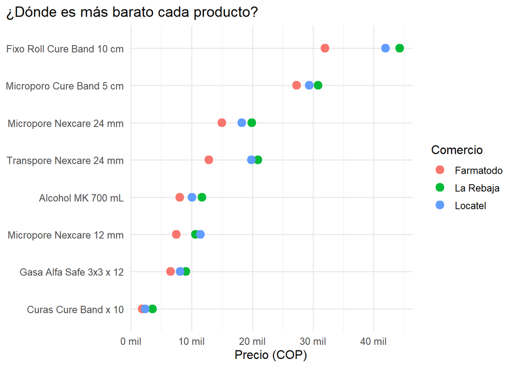

Precio de cada presentación comparable por comercio (fecha de referencia).

```r
datos_ref <- dbGetQuery(con, "
  SELECT     v.*
  FROM       v_comparables v
  INNER JOIN v_referencia  r ON v.fecha = r.fecha;
")
datos_ref$etiqueta <- unname(etiquetas[as.character(datos_ref$id_comparable)])

ggplot(datos_ref, aes(x = precio, y = reorder(etiqueta, precio, FUN = min), color = comercio)) +
  geom_point(size = 3.5) +
  scale_x_continuous(labels = label_number(scale = 1e-3, suffix = " mil", big.mark = "."),
                     breaks = breaks_pretty(n = 5)) +
  labs(x = "Precio (COP)", y = NULL, color = "Comercio",
       title = "¿Dónde es más barato cada producto?") +
  theme_minimal(base_size = 12) +
  theme(plot.title.position = "plot")
```

**Código**

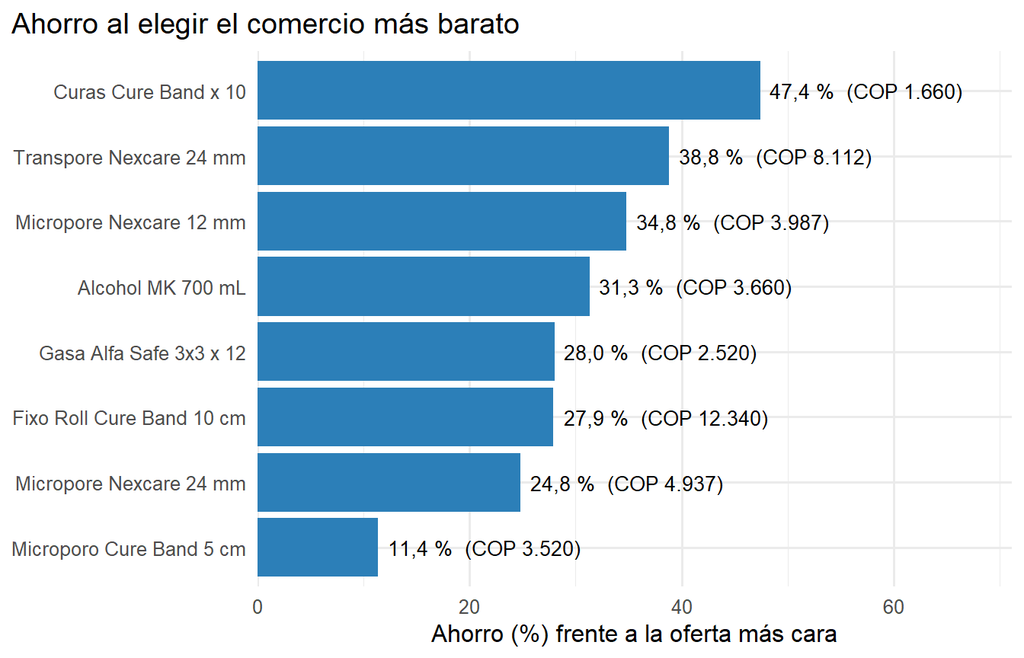

Ahorro porcentual al elegir la oferta más barata frente a la más cara.

```r
q4$etiqueta <- unname(etiquetas[as.character(q4$id)])

ggplot(q4, aes(x = ahorro_pct, y = reorder(etiqueta, ahorro_pct))) +
  geom_col(fill = "#2c7fb8") +
  geom_text(aes(label = paste0(scales::number(ahorro_pct, accuracy = 0.1, decimal.mark = ","),
                               " %  (COP ", scales::number(ahorro_cop, accuracy = 1, big.mark = "."), ")")),
            hjust = -0.05, size = 3.5) +
  scale_x_continuous(expand = expansion(mult = c(0, 0.5))) +
  labs(x = "Ahorro (%) frente a la oferta más cara", y = NULL,
       title = "Ahorro al elegir el comercio más barato") +
  theme_minimal(base_size = 12) +
  theme(plot.title.position = "plot")
```

**Código**

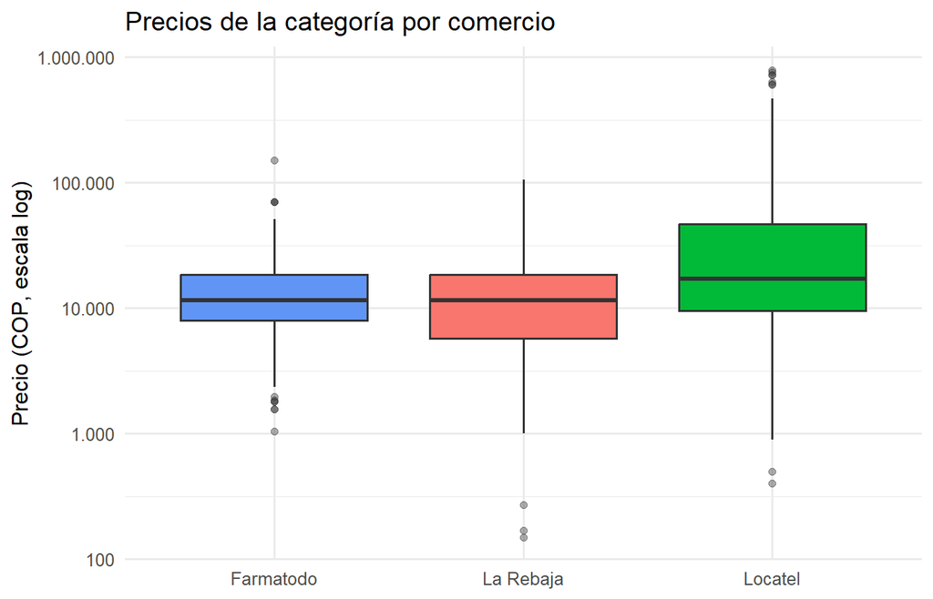

Distribución de precios de toda la categoría por comercio (escala logarítmica).

```r
todos <- dbGetQuery(con, "
  SELECT     c.nombre AS comercio, o.precio
  FROM       observaciones o
  INNER JOIN anuncios  a ON o.id_anuncio  = a.id_anuncio
  INNER JOIN comercios c ON a.id_comercio = c.id_comercio
  WHERE      a.incluido = 1
    AND      o.precio IS NOT NULL
    AND      SUBSTR(o.fecha_hora_consulta, 1, 10) = (SELECT fecha FROM v_referencia);
")
ggplot(todos, aes(x = comercio, y = precio, fill = comercio)) +
  geom_boxplot(show.legend = FALSE, outlier.alpha = 0.4) +
  scale_fill_manual(
    values = c("#6195F5", "#F8766D", "#00BA38"),
    limits = unique(todos$comercio)
  ) +
  scale_y_log10(labels = label_number(big.mark = ".", decimal.mark = ",")) +
  labs(
    x = NULL,
    y = "Precio (COP, escala log)",
    title = "Precios de la categoría por comercio"
  ) +
  theme_minimal(base_size = 12)
```

# 8 Conclusiones

Si se compran los ocho productos siempre en el comercio más barato, la canasta cuesta **COP 110.814**, frente a **COP 151.550** en el más caro: un ahorro potencial de **COP 40.736** (26.9 %).

# 9 Limitaciones